# R Markdown: Output Types (Aside: R Packages)

## R Markdown Basics

**R Markdown Basics**

R Markdown file contains three important types of content:

1. (Optional) YAML header surrounded by `---`s
2. Chunks of R code surrounded by ```
3. Text mixed with simple text formatting like # heading and *italics*

## Where do we go from here?

- Figure out markdown syntax
- Look at "Notebook" feature
- Check options for code chunks
- Change type of output

## Common Outputs

R Markdown really flexible!

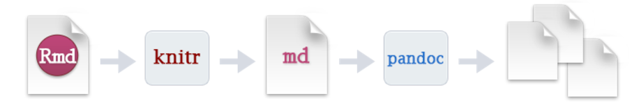

## Common Outputs

Change output type in the YAML header:

- HTML (a web page)

  ```
  output:  html_document
  ```

Use code explicity:

`rmarkdown::render("file.Rmd", output_format = "word_document")`

Use Knit menu:

[figure not shown]

## Common Outputs

For HTML can include Table of Contents with options

```
output:
  html_document:
    toc: true
    toc_float: true
```

## Common Outputs

For HTML can include Table of Contents with options

```
output:
  html_document:
    toc: true
    toc_float: true
```

For html_documents another option is to make the code chunks hidden by default, but visible with a click:

```
output:
  html_document:
    code_folding: hide
```

## Common Outputs

- PDF
- May want to install LaTeX and update its packages

```
output: pdf_document
```

## Common Outputs

- PDF
- May want to install LaTeX for equations

```
output: pdf_document
```

- Word

```
output: word_document
```

- Go back to template, change output type and knit. Add [some HTML options](https://bookdown.org/yihui/rmarkdown/html-document.html) (careful to drop down lines and use spacing as done in documentation).

## Common Outputs

Presentations/Slides (new slides with `##`)

- `output: ioslides_presentation` - HTML presentation
- `slidy_presentation` - HTML presentation
- `beamer_presentation` - PDF presentation with LaTeX Beamer

## Common Outputs

Presentations/Slides (new slides with `##`)

- `output: ioslides_presentation` - HTML presentation
- `slidy_presentation` - HTML presentation
- `beamer_presentation` - PDF presentation with LaTeX Beamer
- Shiny (covered later) slides

```
runtime: shiny
output: html_document
```

or

```
runtime: shiny
output: ioslides_presentation
```

## Interactivity

HTML documents inherently interactive

- Widgets can be included with an **R package**

```r
library(leaflet)
leaflet() %>%
  setView(174.764, -36.877, zoom = 16) %>%
  addTiles() %>%
  addMarkers(174.764, -36.877, popup = "Maungawhau")
```

## Interactivity

[interactive chart not shown]

## R Packages

- R package
  - Collection of functions in one place
  - Packages exist to do almost anything
  - [List of CRAN](https://cran.r-project.org/web/packages/available_packages_by_name.html) approved packages on R's website
  - Plenty of other packages on places like GitHub

## R Packages

- First time using a package
  - Must install package (download)
  - Can use code or menus

```r
install.packages("readr")
#can do multiple packages at once
install.packages(c("readr", "readxl", "haven", "DBI", "httr"))
```

## R Packages

- First time using a package
  - Must install package (download)
  - Can use code or menus

[figure not shown]

## R Packages

- Once 'installed' on computer, never need to install again (unless you update R)
- **Each session** read the package in using `library()` or `require()`

```r
library("readr")
require("haven")
```

## R Packages

- Difference - if no package
  - `library()` throws an error
  - `require()` returns FALSE

```r
library("notAPackage")
```

```
## Error in library("notAPackage"): there is no package called 'notAPackage'
```

```r
require("notAPackage")
```

[output not shown]

## Interactivity

Interactive tables with `DT` library

```r
library(DT)
datatable(iris)
```

## Interactivity

|  | Sepal.Length | Sepal.Width | Petal.Length | Petal.Width | Species |
| --- | --- | --- | --- | --- | --- |
| 1 | 5.1 | 3.5 | 1.4 | 0.2 | setosa |
| 2 | 4.9 | 3 | 1.4 | 0.2 | setosa |
| 3 | 4.7 | 3.2 | 1.3 | 0.2 | setosa |
| 4 | 4.6 | 3.1 | 1.5 | 0.2 | setosa |
| 5 | 5 | 3.6 | 1.4 | 0.2 | setosa |
| 6 | 5.4 | 3.9 | 1.7 | 0.4 | setosa |
| 7 | 4.6 | 3.4 | 1.4 | 0.3 | setosa |
| 8 | 5 | 3.4 | 1.5 | 0.2 | setosa |
| 9 | 4.4 | 2.9 | 1.4 | 0.2 | setosa |
| 10 | 4.9 | 3.1 | 1.5 | 0.1 | setosa |

[output cut: 140 more lines]

## Interactivity

Previous interactivity happened in the browser

- Great because anyone can access with a browser
- Bad because you can't have as much functionality as you want…
- Shiny allows for interactivity with R!
- Only con: Requires R running somewhere

## What do we want to be able to do?

Data Science

- Scrape, read, and manipulate data
- Combine data sources
- Summarize data
- Apply analysis methods
- Communicate Effectively